# Data Analytics and ML: Midterm Exam

Pongsun B.

2026-03-11

# Optimize the Loan Eligibility Process

Dream Housing Finance company deals in all kinds of home loans…

## Data Dictionary

```r
myURL = "https://www.dropbox.com/scl/fi/wn5ow4zvgg4p4odfbor51/LoanPrediction.csv?rlkey=mludfatyg87sgz8374i0h8kfa&st=6kivxmtg&dl=1"

myData = as_tibble(read_csv(myURL, na = c("", " ", NA), show_col_types = FALSE))
myData
```

```
## # A tibble: 614 × 13
##    Loan_ID  Gender Married Dependents Education    Self_Employed ApplicantIncome
##    <chr>    <chr>  <chr>   <chr>      <chr>        <chr>                   <dbl>
##  1 LP001002 Male   No      0          Graduate     No                       5849
##  2 LP001003 Male   Yes     1          Graduate     No                       4583
##  3 LP001005 Male   Yes     0          Graduate     Yes                      3000
##  4 LP001006 Male   Yes     0          Not Graduate No                       2583
##  5 LP001008 Male   No      0          Graduate     No                       6000
##  6 LP001011 Male   Yes     2          Graduate     Yes                      5417
##  7 LP001013 Male   Yes     0          Not Graduate No                       2333
##  8 LP001014 Male   Yes     3+         Graduate     No                       3036
##  9 LP001018 Male   Yes     2          Graduate     No                       4006
## 10 LP001020 Male   Yes     1          Graduate     No                      12841
## # ℹ 604 more rows
## # ℹ 6 more variables: CoapplicantIncome <dbl>, LoanAmount <dbl>,
## #   Loan_Amount_Term <dbl>, Credit_History <dbl>, Property_Area <chr>,
## #   Loan_Status <chr>
```

```r
mlr::summarizeColumns(myData)
```

```
##                 name      type na         mean         disp median       mad
## 1            Loan_ID character  0           NA    0.9983713     NA        NA
## 2             Gender character 13           NA           NA     NA        NA
## 3            Married character  3           NA           NA     NA        NA
## 4         Dependents character 15           NA           NA     NA        NA
## 5          Education character  0           NA    0.2182410     NA        NA
## 6      Self_Employed character 32           NA           NA     NA        NA
## 7    ApplicantIncome   numeric  0 5403.4592834 6109.0416734 3812.5 1822.8567
## 8  CoapplicantIncome   numeric  0 1621.2457980 2926.2483692 1188.5 1762.0701
## 9         LoanAmount   numeric 22  146.4121622   85.5873252  128.0   47.4432
## 10  Loan_Amount_Term   numeric 14  342.0000000   65.1204099  360.0    0.0000
## 11    Credit_History   numeric 50    0.8421986    0.3648783    1.0    0.0000
## 12     Property_Area character  0           NA    0.6205212     NA        NA
## 13       Loan_Status character  0           NA    0.3127036     NA        NA
##    min   max nlevs
## 1    1     1   614
## 2  112   489     2
## 3  213   398     2
## 4   51   345     4
## 5  134   480     2
## 6   82   500     2
## 7  150 81000     0
## 8    0 41667     0
## 9    9   700     0
## 10  12   480     0
## 11   0     1     0
## 12 179   233     3
## 13 192   422     2
```

## Data Manipulation

```r
# Step 1
myData <- myData |>
    mutate(across(where(is.character) & !matches("Loan_ID"), as.factor))

myData <- myData |>
    mutate(Credit_History = factor(Credit_History, levels = c(0, 1), labels = c("No",
        "Yes")))

# Step 2
need_check = c("LoanAmount", "ApplicantIncome", "CoapplicantIncome")

skewness_values <- sapply(myData[, need_check], moments::skewness, na.rm = TRUE)
print(skewness_values)
```

```
##        LoanAmount   ApplicantIncome CoapplicantIncome
##          2.670763          6.523526          7.473217
```

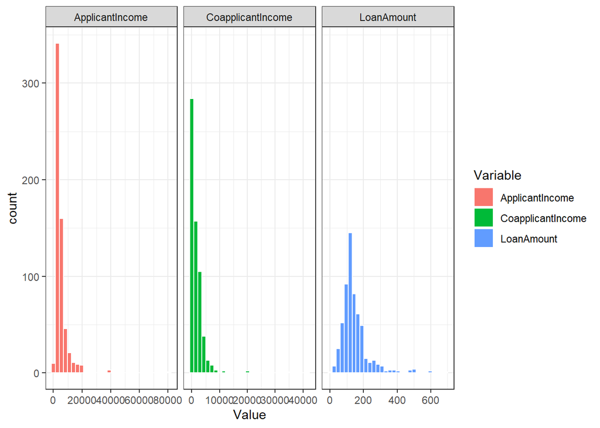

```r
myData |>
    select(all_of(need_check)) |>
    pivot_longer(cols = everything(), names_to = "Variable", values_to = "Value") |>
    ggplot(aes(x = Value, fill = Variable)) + geom_histogram(bins = 30, color = "white") +
    facet_grid(. ~ Variable, scales = "free_x") + labs(x = "Value", y = "count") +
    theme_bw()
```

```r
# Shapiro-Wilk normality test
lapply(myData[, need_check], function(x) shapiro.test(na.omit(x)))
```

```
## $LoanAmount
##
##  Shapiro-Wilk normality test
##
## data:  na.omit(x)
## W = 0.76752, p-value < 2.2e-16
##
##
## $ApplicantIncome
##
##  Shapiro-Wilk normality test
##
## data:  na.omit(x)
## W = 0.47126, p-value < 2.2e-16
##
##
## $CoapplicantIncome
##
##  Shapiro-Wilk normality test
##
## data:  na.omit(x)
## W = 0.4815, p-value < 2.2e-16
```

## Missing Value Imputation

```r
# Impute missing values by mean and mode
myData_imp <- mlr::impute(myData, classes = list(factor = imputeMode(), numeric = imputeMean()))

myData_imputed <- myData_imp$data

myData_imputed$Loan_ID <- NULL

mlr::summarizeColumns(myData_imputed[, 1:12])
```

```
##                 name    type na      mean         disp median       mad min
## 1             Gender  factor  0        NA    0.1824104     NA        NA 112
## 2            Married  factor  0        NA    0.3469055     NA        NA 213
## 3         Dependents  factor  0        NA    0.4136808     NA        NA  51
## 4          Education  factor  0        NA    0.2182410     NA        NA 134
## 5      Self_Employed  factor  0        NA    0.1335505     NA        NA  82
## 6    ApplicantIncome numeric  0 5403.4593 6109.0416734 3812.5 1822.8567 150
## 7  CoapplicantIncome numeric  0 1621.2458 2926.2483692 1188.5 1762.0701   0
## 8         LoanAmount numeric  0  146.4122   84.0374677  129.0   45.2193   9
## 9   Loan_Amount_Term numeric  0  342.0000   64.3724886  360.0    0.0000  12
## 10    Credit_History  factor  0        NA    0.1449511     NA        NA  89
## 11     Property_Area  factor  0        NA    0.6205212     NA        NA 179
## 12       Loan_Status  factor  0        NA    0.3127036     NA        NA 192
##      max nlevs
## 1    502     2
## 2    401     2
## 3    360     4
## 4    480     2
## 5    532     2
## 6  81000     0
## 7  41667     0
## 8    700     0
## 9    480     0
## 10   525     2
## 11   233     3
## 12   422     2
```

## Feature Engineering

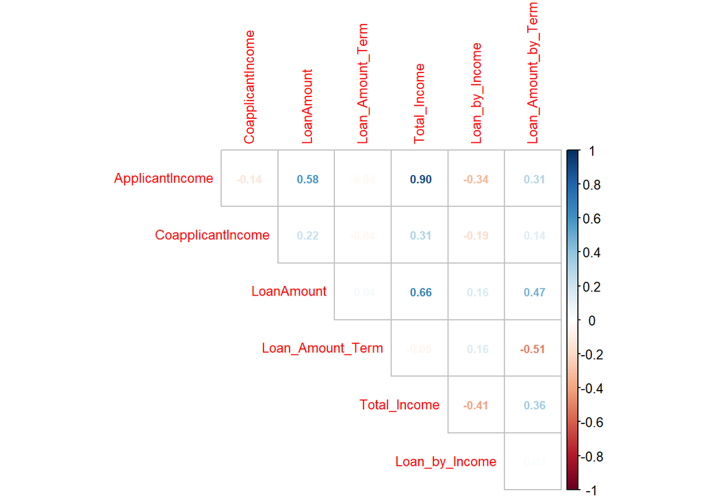

```r
myData_trim <- myData_imputed |>
    capLargeValues(target = "Loan_Status", cols = c("ApplicantIncome"), threshold = 40000) |>
    capLargeValues(target = "Loan_Status", cols = c("CoapplicantIncome"), threshold = 21000) |>
    capLargeValues(target = "Loan_Status", cols = c("LoanAmount"), threshold = 520)

# Step 3: Create new features
myData_added <- myData_trim |>
    mutate(Total_Income = ApplicantIncome + CoapplicantIncome, Loan_by_Income = LoanAmount/Total_Income,
        Loan_Amount_by_Term = LoanAmount/Loan_Amount_Term)

myData_corr <- myData_added |>
    select(where(is.numeric))

cor_matrix <- cor(myData_corr, use = "complete.obs")

corrplot(cor_matrix, method = "number", type = "upper", diag = FALSE, number.cex = 0.7,
    tl.cex = 0.8, addCoef.col = "black", number.digits = 2)
```

```r
myData_final <- myData_added |>
    select(-Total_Income) |>
    mutate(Loan_ID = myData$Loan_ID)
```

## Data Visualization

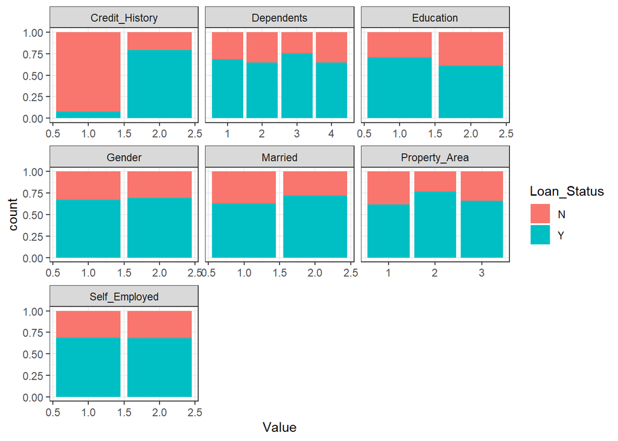

```r
# Step 4

long_data_cat <- myData_final |>
    select(Loan_ID, where(is.factor)) |>
    mutate_at(.vars = vars(-Loan_ID, -Loan_Status), .funs = as.integer) |>
    pivot_longer(names_to = "Variable", values_to = "Value", -c(Loan_ID, Loan_Status))

long_data_cat |>
    ggplot(aes(x = Value, fill = Loan_Status)) + geom_bar(position = "fill") + facet_wrap(~Variable,
    scales = "free_x") + labs(y = "count") + theme_bw()
```

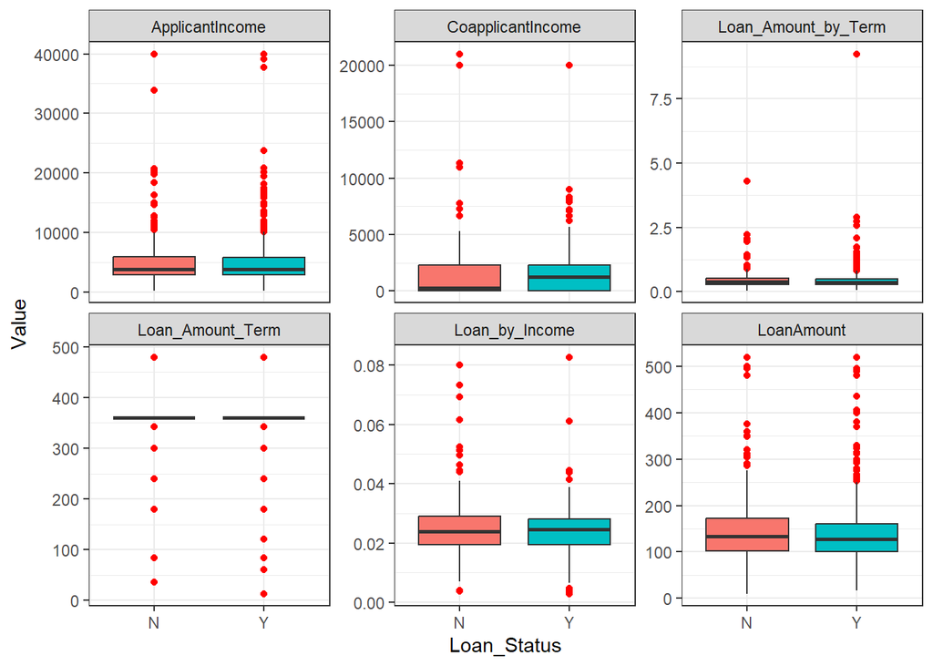

```r
long_data_num <- myData_final |>
    select(Loan_ID, Loan_Status, where(is.numeric)) |>
    pivot_longer(names_to = "Variable", values_to = "Value", -c(Loan_ID, Loan_Status))

long_data_num |>
    ggplot(aes(x = Loan_Status, y = Value, fill = Loan_Status)) + geom_boxplot(outlier.colour = "red",
    outlier.shape = 16) + facet_wrap(~Variable, scales = "free_y") + theme_bw() +
    theme(legend.position = "none") + labs(x = "Loan_Status", y = "Value")
```

## Hypothesis Testing

```r
# Step 5

chi_results <- long_data_cat |>
    split(f = long_data_cat$Variable) |>
    lapply(function(df) chisq.test(table(df$Value, df$Loan_Status)))

cat("Chi-Square p-values:\n")
```

```
## Chi-Square p-values:
```

```r
sapply(chi_results, function(x) x$p.value)
```

```
## Credit_History     Dependents      Education         Gender        Married
##   3.418350e-40   3.688663e-01   4.309962e-02   7.391461e-01   2.960858e-02
##  Property_Area  Self_Employed
##   2.136019e-03   1.000000e+00
```

```r
kw_results <- long_data_num |>
    split(f = long_data_num$Variable) |>
    lapply(function(df) kruskal.test(Value ~ Loan_Status, data = df))

cat("\nKruskal-Wallis p-values:\n")
```

```
##
## Kruskal-Wallis p-values:
```

```r
sapply(kw_results, function(x) x$p.value)
```

```
##     ApplicantIncome   CoapplicantIncome Loan_Amount_by_Term    Loan_Amount_Term
##           0.9183090           0.3867325           0.2792997           0.7705830
##      Loan_by_Income          LoanAmount
##           0.4317761           0.2816914
```

## Create the Task

```r
myData_train <- myData_final |>
    select(-Loan_ID)

myTask <- makeClassifTask(data = myData_train, target = "Loan_Status")
myTask <- normalizeFeatures(myTask)
str(getTaskData(myTask))
```

```
## 'data.frame':    614 obs. of  14 variables:
##  $ Gender             : Factor w/ 2 levels "Female","Male": 2 2 2 2 2 2 2 2 2 2 ...
##  $ Married            : Factor w/ 2 levels "No","Yes": 1 2 2 2 1 2 2 2 2 2 ...
##  $ Dependents         : Factor w/ 4 levels "0","1","2","3+": 1 2 1 1 1 3 1 4 3 2 ...
##  $ Education          : Factor w/ 2 levels "Graduate","Not Graduate": 1 1 1 2 1 1 2 1 1 1 ...
##  $ Self_Employed      : Factor w/ 2 levels "No","Yes": 1 1 2 1 1 2 1 1 1 1 ...
##  $ ApplicantIncome    : num  0.114 -0.14 -0.457 -0.541 0.145 ...
##  $ CoapplicantIncome  : num  -0.6695 -0.0251 -0.6695 0.3382 -0.6695 ...
##  $ LoanAmount         : num  0.0107 -0.2209 -1.0007 -0.3215 -0.0574 ...
##  $ Loan_Amount_Term   : num  0.28 0.28 0.28 0.28 0.28 ...
##  $ Credit_History     : Factor w/ 2 levels "No","Yes": 2 2 2 2 2 2 2 1 2 2 ...
##  $ Property_Area      : Factor w/ 3 levels "Rural","Semiurban",..: 3 1 3 3 3 3 3 2 3 2 ...
##  $ Loan_Status        : Factor w/ 2 levels "N","Y": 2 1 2 2 2 2 2 1 2 1 ...
##  $ Loan_by_Income     : num  0.1135 -0.3381 -0.2273 0.0297 -0.0587 ...
##  $ Loan_Amount_by_Term: num  -0.133 -0.235 -0.577 -0.279 -0.163 ...
```

## Discriminant Analysis

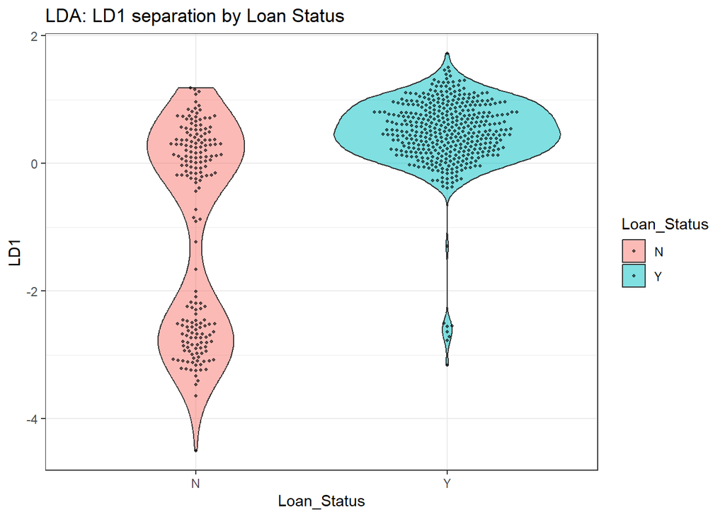

```r
# ── LDA ─────────────────────────────────────────────────────────────────────
lda <- makeLearner("classif.lda", predict.type = "response")
lda_model <- mlr::train(lda, myTask)
lda_raw <- getLearnerModel(lda_model)


lda_scores <- data.frame(LD1 = as.numeric(predict(lda_raw, newdata = as.data.frame(getTaskData(myTask)))$x[,
    1]), Loan_Status = getTaskData(myTask)$Loan_Status)

ggplot(lda_scores, aes(x = Loan_Status, y = LD1, fill = Loan_Status)) + geom_violin(alpha = 0.5) +
    geom_beeswarm(size = 0.8, alpha = 0.6) + theme_bw() + labs(title = "LDA: LD1 separation by Loan Status")
```

```r
# 10-fold Repeated CV
cv_desc <- makeResampleDesc("RepCV", folds = 10, reps = 50)

lda_cv <- resample(lda, myTask, resampling = cv_desc, measures = list(acc, mmce),
    show.info = FALSE)

mlr::calculateConfusionMatrix(lda_cv$pred, relative = TRUE)
```

```
## Relative confusion matrix (normalized by row/column):
##         predicted
## true     N         Y         -err.-
##   N      0.44/0.90 0.56/0.21 0.56
##   Y      0.02/0.10 0.98/0.79 0.02
##   -err.-      0.10      0.21 0.19
##
##
## Absolute confusion matrix:
##         predicted
## true        N     Y -err.-
##   N      4186  5414   5414
##   Y       470 20630    470
##   -err.-  470  5414   5884
```

```r
caret::confusionMatrix(data = lda_cv$pred$data$response, reference = lda_cv$pred$data$truth,
    positive = "Y")
```

```
## Confusion Matrix and Statistics
##
##           Reference
## Prediction     N     Y
##          N  4186   470
##          Y  5414 20630
##
##                Accuracy : 0.8083
##                  95% CI : (0.8039, 0.8127)
##     No Information Rate : 0.6873
##     P-Value [Acc > NIR] : < 2.2e-16
##
##                   Kappa : 0.4813
##
##  Mcnemar's Test P-Value : < 2.2e-16
##
##             Sensitivity : 0.9777
##             Specificity : 0.4360
##          Pos Pred Value : 0.7921
##          Neg Pred Value : 0.8991
##              Prevalence : 0.6873
##          Detection Rate : 0.6720
##    Detection Prevalence : 0.8483
##       Balanced Accuracy : 0.7069
##
##        'Positive' Class : Y
##
```

```r
# QDA
qda <- makeLearner("classif.qda", predict.type = "response")

qda_cv <- resample(qda, myTask, resampling = cv_desc, measures = list(acc, mmce),
    show.info = FALSE)

mlr::calculateConfusionMatrix(qda_cv$pred, relative = TRUE)
```

```
## Relative confusion matrix (normalized by row/column):
##         predicted
## true     N         Y         -err.-
##   N      0.49/0.77 0.51/0.20 0.51
##   Y      0.07/0.23 0.93/0.80 0.07
##   -err.-      0.23      0.20 0.20
##
##
## Absolute confusion matrix:
##         predicted
## true        N     Y -err.-
##   N      4694  4906   4906
##   Y      1380 19720   1380
##   -err.- 1380  4906   6286
```

```r
caret::confusionMatrix(data = qda_cv$pred$data$response, reference = qda_cv$pred$data$truth,
    positive = "Y")
```

```
## Confusion Matrix and Statistics
##
##           Reference
## Prediction     N     Y
##          N  4694  1380
##          Y  4906 19720
##
##                Accuracy : 0.7952
##                  95% CI : (0.7907, 0.7997)
##     No Information Rate : 0.6873
##     P-Value [Acc > NIR] : < 2.2e-16
##
##                   Kappa : 0.4707
##
##  Mcnemar's Test P-Value : < 2.2e-16
##
##             Sensitivity : 0.9346
##             Specificity : 0.4890
##          Pos Pred Value : 0.8008
##          Neg Pred Value : 0.7728
##              Prevalence : 0.6873
##          Detection Rate : 0.6423
##    Detection Prevalence : 0.8021
##       Balanced Accuracy : 0.7118
##
##        'Positive' Class : Y
##
```

## Support Vector Machines

```r
library(mlr)
library(ggplot2)
library(parallelMap)


parallelStartSocket(cpus = parallel::detectCores() - 1)

svm <- makeLearner("classif.svm", predict.type = "response")


svmParamSpace <- makeParamSet(makeNumericParam("cost", lower = 0.1, upper = 10),
    makeNumericParam("gamma", lower = 0.1, upper = 10))


randControl <- makeTuneControlRandom(maxit = 50)
holdout_desc <- makeResampleDesc("Holdout", split = 0.8)

set.seed(42)
svm_rand_tune <- tuneParams(learner = svm, task = myTask, resampling = holdout_desc,
    par.set = svmParamSpace, control = randControl)

cat("Random Search Results:\n")
```

```
## Random Search Results:
```

```r
print(svm_rand_tune)
```

```
## Tune result:
## Op. pars: cost=8.29; gamma=0.136
## mmce.test.mean=0.1788618
```

```r
gridControl <- makeTuneControlGrid(resolution = 10)

set.seed(42)
svm_grid_tune <- tuneParams(learner = svm, task = myTask, resampling = holdout_desc,
    par.set = svmParamSpace, control = gridControl)

cat("\nGrid Search Results:\n")
```

```
##
## Grid Search Results:
```

```r
print(svm_grid_tune)
```

```
## Tune result:
## Op. pars: cost=1.2; gamma=0.1
## mmce.test.mean=0.1626016
```

```r
svm_wrapper <- makeTuneWrapper(learner = svm, resampling = holdout_desc, par.set = svmParamSpace,
    control = randControl, show.info = FALSE)

outer_cv <- makeResampleDesc("CV", iters = 5)

set.seed(42)
svm_nested_cv <- resample(svm_wrapper, myTask, resampling = outer_cv, measures = list(acc,
    mmce), show.info = FALSE)
print(svm_nested_cv)
```

```
## Resample Result
## Task: myData_train
## Learner: classif.svm.tuned
## Aggr perf: acc.test.mean=0.7865787,mmce.test.mean=0.2134213
## Runtime: 3.76604
```

```r
svm_tuned <- setHyperPars(svm, cost = svm_grid_tune$x$cost, gamma = svm_grid_tune$x$gamma)

svm_model <- mlr::train(svm_tuned, myTask)

parallelStop()
```

## Decision Tree

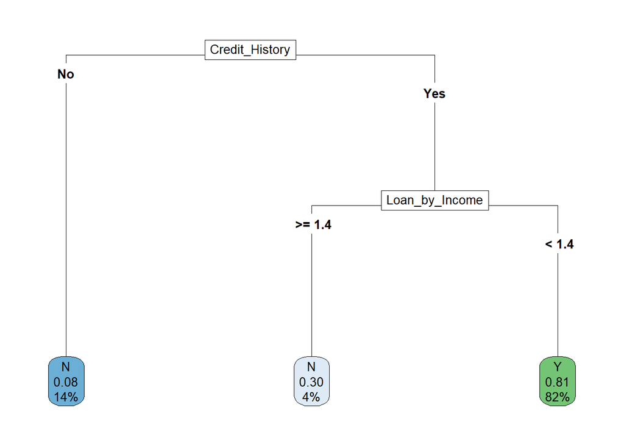

```r
library(mlr)
library(parallelMap)
library(rpart.plot)

tree <- makeLearner("classif.rpart", predict.type = "response")

# Defining the hyperparameter space
treeParamSpace <- makeParamSet(makeIntegerParam("minsplit", lower = 5, upper = 20),
    makeIntegerParam("minbucket", lower = 3, upper = 10), makeNumericParam("cp",
        lower = 0.01, upper = 0.1), makeIntegerParam("maxdepth", lower = 3, upper = 10))


cv5_desc <- makeResampleDesc("CV", iters = 5)
treeControl <- makeTuneControlRandom(maxit = 50)

parallelStartSocket(cpus = parallel::detectCores() - 1)

set.seed(42)
tree_tune <- tuneParams(learner = tree, task = myTask, resampling = cv5_desc, par.set = treeParamSpace,
    control = treeControl)

parallelStop()

# ── Nested CV ────────────────────────────────────────────────────────────────
tree_wrapper <- makeTuneWrapper(learner = tree, resampling = cv5_desc, par.set = treeParamSpace,
    control = treeControl, show.info = FALSE)

set.seed(42)
tree_nested_cv <- resample(tree_wrapper, myTask, resampling = makeResampleDesc("CV",
    iters = 5), measures = list(acc, mmce), show.info = FALSE)

# ── Train final tree ─────────────────────────────────────────────────────────
tree_tuned <- setHyperPars(tree, par.vals = tree_tune$x)

tree_model <- mlr::train(tree_tuned, myTask)
tree_model_data <- getLearnerModel(tree_model)

rpart.plot(tree_model_data, type = 5, box.palette = "BuGn", fallen.leaves = TRUE,
    tweak = 1.2, cex = 0.7, roundint = FALSE)
```

```r
# Complexity parameter table
printcp(tree_model_data)
```

```
##
## Classification tree:
## rpart::rpart(formula = f, data = d, xval = 0, minsplit = 10,
##     minbucket = 10, cp = 0.0222882989514619, maxdepth = 10)
##
## Variables actually used in tree construction:
## [1] Credit_History Loan_by_Income
##
## Root node error: 192/614 = 0.3127
##
## n= 614
##
##         CP nsplit rel error
## 1 0.390625      0   1.00000
## 2 0.046875      1   0.60938
## 3 0.022288      2   0.56250
```

## Random Forest

```r
forest <- mlr::makeLearner("classif.randomForest")


forestParamSpace <- makeParamSet(makeIntegerParam("ntree", lower = 30, upper = 30),
    makeIntegerParam("mtry", lower = 6, upper = 12), makeIntegerParam("nodesize",
        lower = 1, upper = 5), makeIntegerParam("maxnodes", lower = 5, upper = 20))


forestControl <- makeTuneControlRandom(maxit = 100)

parallelStartSocket(cpus = detectCores() - 1)

set.seed(42)
forest_tune <- tuneParams(learner = forest, task = myTask, resampling = cv5_desc,
    par.set = forestParamSpace, control = forestControl)

parallelStop()

# ── Nested CV
forest_wrapper <- makeTuneWrapper(learner = forest, resampling = cv5_desc, par.set = forestParamSpace,
    control = forestControl, show.info = FALSE)

set.seed(42)
forest_nested_cv <- resample(forest_wrapper, myTask, resampling = makeResampleDesc("CV",
    iters = 5), measures = list(acc, mmce), show.info = FALSE)
forest_nested_cv
```

```
## Resample Result
## Task: myData_train
## Learner: classif.randomForest.tuned
## Aggr perf: acc.test.mean=0.8159403,mmce.test.mean=0.1840597
## Runtime: 74.6083
```

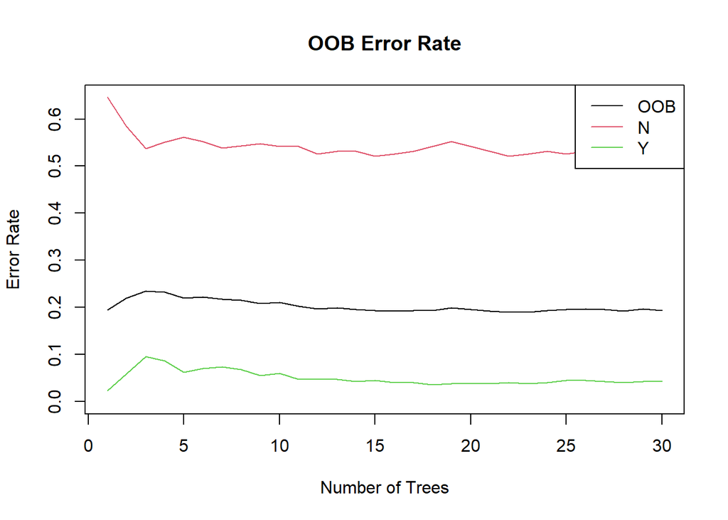

```r
# ── Train final forest
forest_tuned <- setHyperPars(forest, ntree = forest_tune$x$ntree, mtry = forest_tune$x$mtry,
    nodesize = forest_tune$x$nodesize, maxnodes = forest_tune$x$maxnodes)

forest_model <- mlr::train(forest_tuned, myTask)
forest_model_data <- getLearnerModel(forest_model)

# ── OOB error plot
oob_error <- forest_model_data$err.rate
n_classes <- ncol(oob_error) - 1  # number of class columns

plot(oob_error[, "OOB"], type = "l", ylim = c(0, max(oob_error, na.rm = TRUE)), xlab = "Number of Trees",
    ylab = "Error Rate", main = "OOB Error Rate", col = 1)

colors_cls <- 2:(n_classes + 1)
for (i in seq_len(n_classes)) {
    lines(oob_error[, i + 1], col = colors_cls[i])
}

legend("topright", legend = colnames(oob_error), col = c(1, colors_cls), lty = 1)
```

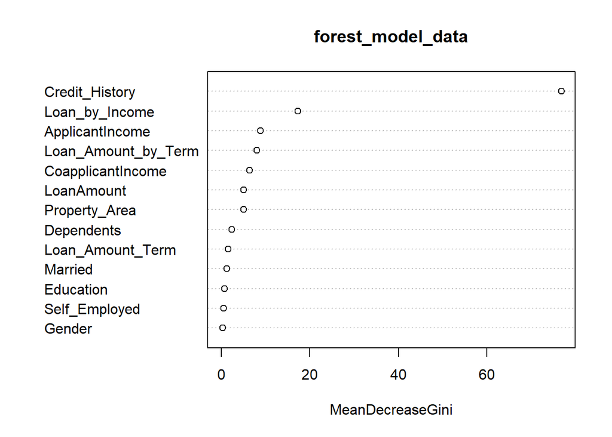

```r
# ── Variable Importance plot
randomForest::varImpPlot(forest_model_data)
```

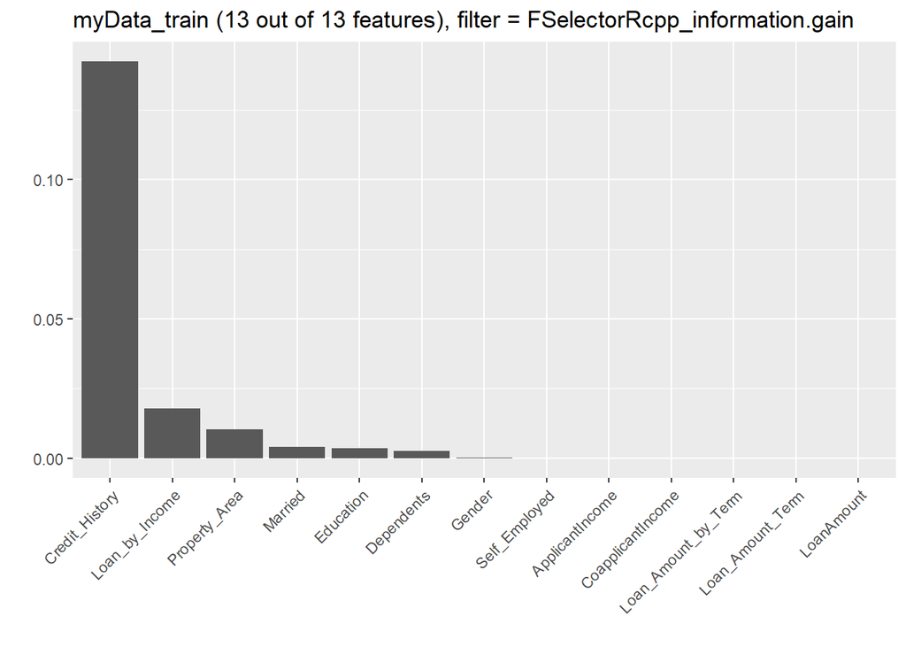

```r
# ── Information Gain feature filter
filter_data <- generateFilterValuesData(myTask, method = "FSelectorRcpp_information.gain")
plotFilterValues(filter_data)
```

## Benchmarking

```r
# Combine five learners into a list
lda_lrn <- makeLearner("classif.lda")
qda_lrn <- makeLearner("classif.qda")

# Re-use the tuned wrappers / tuned learner objects
learner_list <- list(lda_lrn, qda_lrn, svm_tuned, tree_tuned, forest_tuned)

# Benchmark with RepCV (10 folds, 10 reps)
bench_cv <- makeResampleDesc("RepCV", folds = 10, reps = 10)

set.seed(42)
bench_result <- mlr::benchmark(learners = learner_list, tasks = myTask, resamplings = bench_cv,
    measures = list(mmce, acc, fpr, fnr), show.info = FALSE)

bench_result
```

```
##        task.id           learner.id mmce.test.mean acc.test.mean fpr.test.mean
## 1 myData_train          classif.lda      0.1925278     0.8074722    0.02267508
## 2 myData_train          classif.qda      0.2052300     0.7947700    0.06457067
## 3 myData_train          classif.svm      0.1936330     0.8063670    0.02799036
## 4 myData_train        classif.rpart      0.1776785     0.8223215    0.03534916
## 5 myData_train classif.randomForest      0.1886092     0.8113908    0.03532839
##   fnr.test.mean
## 1     0.5641151
## 2     0.5105726
## 3     0.5550611
## 4     0.4858428
## 5     0.5225854
```

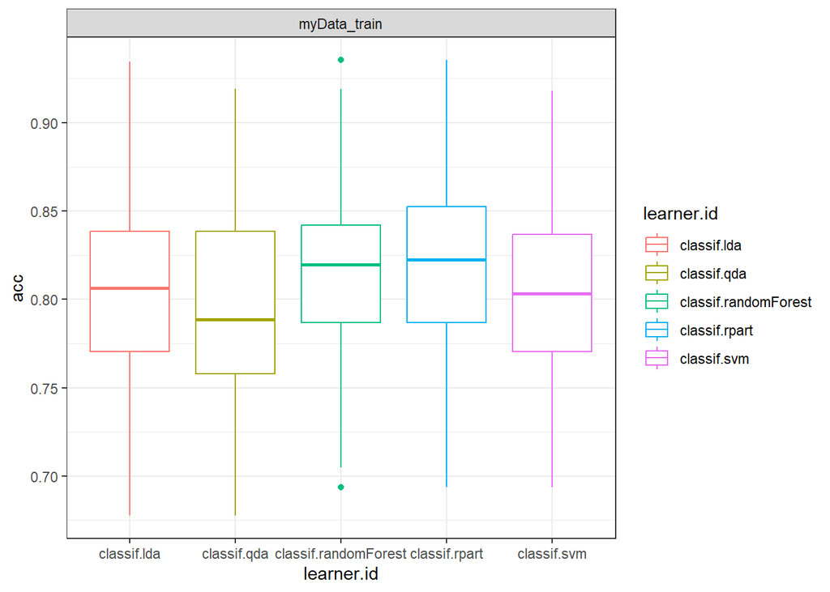

```r
# ── Boxplots of accuracy ─────────────────────────────────────────────────────
plotBMRBoxplots(bench_result, measure = acc, style = "box", pretty.names = FALSE) +
    aes(colour = learner.id) + theme_bw()
```

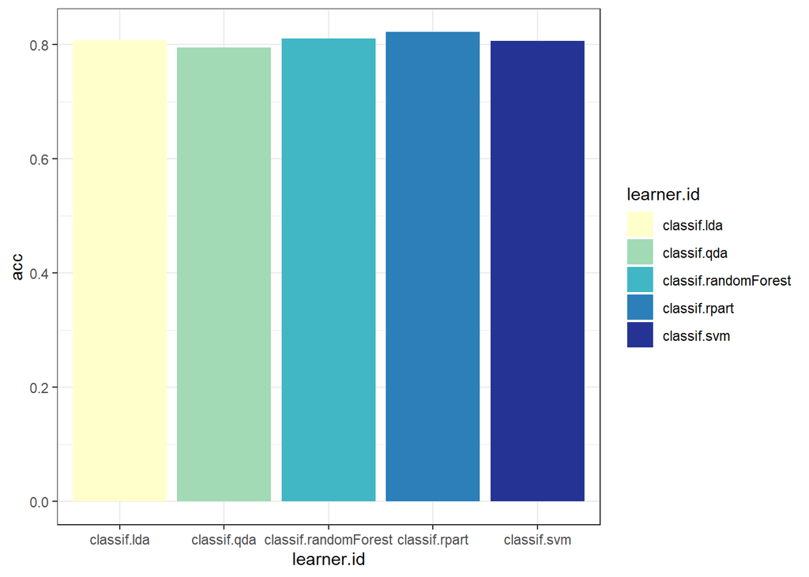

```r
# ── Bar chart of average accuracy ────────────────────────────────────────────
bench_df <- as.data.frame(bench_result)

ggplot(bench_df, aes(x = learner.id, y = acc, fill = learner.id)) + stat_summary(geom = "bar",
    fun = "mean") + scale_fill_brewer(palette = "YlGnBu") + labs(x = "learner.id",
    y = "acc") + theme_bw()
```

## Discussion

**Q1: Why couldn’t we use the k-Nearest Neighbors (kNN) algorithm easily on this dataset?**

A1: kNN เป็น **instance-based learner** ที่ต้องใช้การคำนวณ distance ระหว่างข้อมูลแต่ละตัว ดังนั้นโดยปกติจะต้องใช้ข้อมูลที่เป็น **numeric ทั้งหมด** แต่ใน dataset นี้มีตัวแปรที่เป็น **categorical/factor หลายตัว** เช่น Gender, Married, Education, Self_Employed, Credit_History, Property_Area และ Dependents ทำให้ไม่สามารถนำไปคำนวณ distance ได้โดยตรง

ถึงแม้จะสามารถ encode ตัวแปรเหล่านี้ให้เป็นตัวเลขได้ แต่ก็ยังมีปัญหาเรื่อง **scale ของแต่ละ feature ที่ต่างกัน** ซึ่งจะส่งผลต่อการคำนวณ distance ทำให้ต้องทำ normalization เพิ่มอีกขั้นตอน นอกจากนี้ kNN ยังมีข้อจำกัดเรื่อง **curse of dimensionality** เมื่อจำนวน feature เพิ่มขึ้น ซึ่งอาจทำให้ประสิทธิภาพของโมเดลลดลงได้

**Q2: In the context of the Dream Housing Finance company, evaluate the importance of the model’s Sensitivity versus Specificity. Which metric matters more for their business?**

A2: ในบริบทของบริษัท Dream Housing Finance ค่า **Sensitivity (Recall)** ถือว่าสำคัญกว่า เนื่องจาก Sensitivity วัดความสามารถของโมเดลในการจำแนกลูกค้าที่ **ควรได้รับสินเชื่อ** ได้ถูกต้อง (True Positive Rate) หากค่า Sensitivity ต่ำ บริษัทอาจปฏิเสธลูกค้าที่มีคุณสมบัติเหมาะสมจริง ๆ ซึ่งหมายถึงการเสียโอกาสในการปล่อยสินเชื่อและรายได้จากดอกเบี้ย

อย่างไรก็ตาม **Specificity** ก็ยังมีความสำคัญเช่นกัน เพราะเป็นตัวชี้วัดความสามารถในการจำแนกลูกค้าที่ **ไม่ควรได้รับสินเชื่อ** ซึ่งช่วยลดความเสี่ยงของการเกิด **NPL (Non-Performing Loan)**

ดังนั้นในทางปฏิบัติ บริษัทควรให้ความสำคัญกับ **Sensitivity เป็นหลัก** เพื่อไม่พลาดลูกค้าที่ดี แต่ก็ต้องควบคุม **Specificity** ไม่ให้ต่ำเกินไป เพื่อรักษาสมดุลระหว่างการเติบโตของสินเชื่อและความเสี่ยงทางการเงิน

**Q3: Look at the Variable Importance plots generated in Step 9. Which feature was identified as the most dominant predictor of Loan_Status? Does this align with real-world financial logic?**

A3: จากกราฟ **Variable Importance** และค่า **Information Gain** พบว่าตัวแปรที่มีความสำคัญมากที่สุดในการทำนาย **Loan_Status** คือ **Credit_History** โดยมีค่า MeanDecreaseGini และ Information Gain สูงกว่าตัวแปรอื่นอย่างชัดเจน

ผลลัพธ์นี้ถือว่าสอดคล้องกับตรรกะในโลกการเงินจริง เพราะ **ประวัติการชำระหนี้ (credit history)** เป็นหนึ่งในปัจจัยสำคัญที่สุดที่สถาบันการเงินใช้ในการประเมินความน่าเชื่อถือของผู้กู้ ลูกค้าที่มีประวัติการชำระหนี้ดีมักมีความเสี่ยงผิดนัดชำระต่ำ จึงมีโอกาสได้รับการอนุมัติสินเชื่อสูงกว่า

End-of-File  
2026-03-11